##### This is the first cell with a clickable link to the [GitHub Page](https://swesterfer.github.io)

# Shane Westerfer and Jared Blavatt

## Intro to Data Science Tutorial

[SAT Scores Data](https://corgis-edu.github.io/corgis/csv/school_scores)  
[State Demographics Data](https://corgis-edu.github.io/corgis/csv/state_demographics/)  
The SAT Scores data set provides a comprehensive overview of a decade’s worth of SAT score averages from 2005- 2015 broken down by state. The data set provides a frequency distribution on income brackets and breaks down average scores by these family income brackets, namely: less than 20k, 20-40k, 40-60k, 60-80k, and more than 100k. Additionally, the data set provides average scores as well as a frequency distribution of score ranges grouped by gender. Furthermore, there is some additional context of academic strength in the form of average GPA and average years taken of Arts/Music, English, Foreign Languages, Mathematics, Natural Sciences, and Social Sciences, but these will not be utilized as heavily in the tutorial. Instead, we will look to identify correlations by combining the SAT scores from 2007 - 2014 with the CORGIS State Demographics data set.  
The States Demographics data set gives a view of information collected from the United States Census Bureau over the years 2007 - 2014, however the information provided is a condensed and summarized set of data from 2015 broken up between all 50 of the states. The data set differentiates between those whose education ended with a high school degree or above compared to those who have attained a bachelor's degree or above. Employment is classified as farm or non-farm related, and it includes a percent change for the non-farm sector to give context to what areas are urbanizing. Beyond exploring the well-established trend of income vs. average score, we can investigate how much a change from one income bracket to another affects SAT score improvements i.e. are there diminishing returns, or if it affects both verbal and math scores equally. The data set also contains information pertaining to languages spoken in a household, firm ownership/employment, and home ownership, among other things. These miscellaneous points of data can be used to build a profile of the type of environment that creates higher standardized test scores, or how higher test scores can be indicative of higher/lower values in these areas.  
**Questions to Consider for the Combined SAT Scores and State Demographics Data:**  
</p>

- What is the relationship between prevalence of farms and average SAT scores? Does it affect male and female scores in the same way?
- Do states with a higher presence of bachelor degrees or higher perform better on the SATs?
- Do states with a higher home ownership rate perform better on the SATs?
- Do states with a lower person per household ratio perform better on the SATs?
- Do states with a higher rate of living stability (i.e. rate of households that have been living in the same house 1+ years) perform better on the SATs?
- Do states with a lower average commute time perform better on the SATs?
- Do states with a higher rate of languages other than English at home typically see a lower SAT verbal score?
- Do states with higher average female scores typically see a higher rate of female-owned firms?

# DATA COLLECTION AND DATA PROCESSING

Let us begin by loading our data sets. First: **SAT Scores** as `df_sat`.

```python
import pandas as pd
import numpy as np
%matplotlib inline

df_sat = pd.read_csv("school_scores.csv")

df_sat.head()
```

|  | Year | State.Code | State.Name | Total.Math | Total.Test-takers | Total.Verbal | Academic Subjects.Arts/Music.Average GPA | Academic Subjects.Arts/Music.Average Years | Academic Subjects.English.Average GPA | Academic Subjects.English.Average Years | ... | Score Ranges.Between 600 to 700.Math.Total | Score Ranges.Between 600 to 700.Verbal.Females | Score Ranges.Between 600 to 700.Verbal.Males | Score Ranges.Between 600 to 700.Verbal.Total | Score Ranges.Between 700 to 800.Math.Females | Score Ranges.Between 700 to 800.Math.Males | Score Ranges.Between 700 to 800.Math.Total | Score Ranges.Between 700 to 800.Verbal.Females | Score Ranges.Between 700 to 800.Verbal.Males | Score Ranges.Between 700 to 800.Verbal.Total |
| --- | --- | --- | --- | --- | --- | --- | --- | --- | --- | --- | --- | --- | --- | --- | --- | --- | --- | --- | --- | --- | --- |
| 0 | 2005 | AL | Alabama | 559 | 3985 | 567 | 3.92 | 2.2 | 3.53 | 3.9 | ... | 1096 | 596 | 613 | 1209 | 156 | 292 | 448 | 219 | 250 | 469 |
| 1 | 2005 | AK | Alaska | 519 | 3996 | 523 | 3.76 | 1.9 | 3.35 | 3.9 | ... | 787 | 423 | 375 | 798 | 47 | 116 | 163 | 109 | 115 | 224 |
| 2 | 2005 | AZ | Arizona | 530 | 18184 | 526 | 3.85 | 2.1 | 3.45 | 3.9 | ... | 3814 | 1831 | 1679 | 3510 | 327 | 630 | 957 | 412 | 501 | 913 |
| 3 | 2005 | AR | Arkansas | 552 | 1600 | 563 | 3.90 | 2.2 | 3.61 | 4.0 | ... | 443 | 242 | 226 | 468 | 49 | 83 | 132 | 77 | 93 | 170 |
| 4 | 2005 | CA | California | 522 | 186552 | 504 | 3.76 | 1.8 | 3.32 | 3.8 | ... | 37605 | 16078 | 14966 | 31044 | 5451 | 8792 | 14243 | 5011 | 4766 | 9777 |

5 rows × 99 columns

Now let's load **State Demographics** as `df_states`.

```python
df_states = pd.read_csv("state_demographics.csv")

df_states.head()
```

|  | State | Age.Percent 65 and Older | Age.Percent Under 18 Years | Age.Percent Under 5 Years | Education.Bachelor's Degree or Higher | Education.High School or Higher | Employment.Nonemployer Establishments | Employment.Private Non-farm Employment | Employment.Private Non-farm Employment Percent Change | Employment.Private Non-farm Establishments | ... | Sales.Merchant Wholesaler Sales | Sales.Retail Sales | Sales.Retail Sales per Capita | Employment.Firms.American Indian-Owned | Employment.Firms.Asian-Owned | Employment.Firms.Black-Owned | Employment.Firms.Hispanic-Owned | Employment.Firms.Native Hawaiian and Other Pacific Islander-Owned | Employment.Firms.Total | Employment.Firms.Women-Owned |
| --- | --- | --- | --- | --- | --- | --- | --- | --- | --- | --- | --- | --- | --- | --- | --- | --- | --- | --- | --- | --- | --- |
| 0 | United States | 14.5 | 23.1 | 6.2 | 28.8 | 86.0 | 23005620 | 118266253 | 2.0 | 7488353 | ... | 41742865 | 39176634 | 12990 | 0.9 | 5.7 | 7.1 | 8.3 | 0.1 | 27092908 | 28.8 |
| 1 | Alabama | 15.3 | 22.8 | 6.1 | 22.6 | 83.1 | 311578 | 1603100 | 1.1 | 97578 | ... | 522527 | 573448 | 12364 | 0.8 | 1.8 | 14.8 | 1.2 | 0.1 | 382350 | 28.1 |
| 2 | Alaska | 9.4 | 25.3 | 7.4 | 27.5 | 91.6 | 52991 | 266627 | 3.3 | 20519 | ... | 45636 | 93033 | 13635 | 10.0 | 3.1 | 1.5 | 0.0 | 0.3 | 68728 | 25.9 |
| 3 | Arizona | 15.9 | 24.1 | 6.4 | 26.9 | 85.7 | 420233 | 2173205 | 1.8 | 132762 | ... | 575734 | 867588 | 13637 | 1.9 | 3.3 | 2.0 | 10.7 | 0.0 | 491529 | 28.1 |
| 4 | Arkansas | 15.7 | 23.8 | 6.5 | 20.1 | 83.7 | 191530 | 978094 | 0.0 | 64772 | ... | 296597 | 329742 | 11602 | 1.1 | 1.4 | 5.5 | 2.3 | 0.1 | 238994 | 24.5 |

5 rows × 51 columns

Thanks to the folks at CORGIS, these two tables are very clean. We will just need to do some manual work to join the two in a meaningful manner.

One problem we should note is that `df_sat` data has 11 observations per state, 1 for each year from 2005 to 2015 (inclusive) and the `df_states` data set has 1 observation per state as an average of values from 2007-2014 (inclusive.) In order to align these date sets more reasonably, we will average values from the `df_sat` dataset over 2007-2014 so as to have one summary observation per state like `df_states`.

```python
# Get slice of 2007-2014 observations
df_sat_2007_2014 = df_sat.loc[(df_sat["Year"] >= 2007) & (df_sat["Year"] <= 2014)]

# Group by state code
groups = df_sat_2007_2014.groupby("State.Name")

# Average values by group, store in df_sat_agg
df_sat_agg = groups.agg(np.mean)

df_sat_agg.head()
```

| State.Name | Year | Total.Math | Total.Test-takers | Total.Verbal | Academic Subjects.Arts/Music.Average GPA | Academic Subjects.Arts/Music.Average Years | Academic Subjects.English.Average GPA | Academic Subjects.English.Average Years | Academic Subjects.Foreign Languages.Average GPA | Academic Subjects.Foreign Languages.Average Years | ... | Score Ranges.Between 600 to 700.Math.Total | Score Ranges.Between 600 to 700.Verbal.Females | Score Ranges.Between 600 to 700.Verbal.Males | Score Ranges.Between 600 to 700.Verbal.Total | Score Ranges.Between 700 to 800.Math.Females | Score Ranges.Between 700 to 800.Math.Males | Score Ranges.Between 700 to 800.Math.Total | Score Ranges.Between 700 to 800.Verbal.Females | Score Ranges.Between 700 to 800.Verbal.Males | Score Ranges.Between 700 to 800.Verbal.Total |
| --- | --- | --- | --- | --- | --- | --- | --- | --- | --- | --- | --- | --- | --- | --- | --- | --- | --- | --- | --- | --- | --- |
| Alabama | 2010.5 | 547.000 | 3553.750 | 552.500 | 3.90375 | 2.275 | 3.59875 | 3.9000 | 3.57750 | 2.6000 | ... | 987.500 | 567.375 | 477.250 | 1044.875 | 186.250 | 297.625 | 483.875 | 244.250 | 256.625 | 500.875 |
| Alaska | 2010.5 | 517.875 | 3809.000 | 519.750 | 3.79125 | 2.025 | 3.46875 | 3.8875 | 3.42750 | 2.2750 | ... | 820.000 | 458.000 | 378.875 | 836.875 | 121.000 | 177.500 | 298.500 | 175.125 | 154.250 | 329.375 |
| Arizona | 2010.5 | 525.875 | 21462.375 | 518.500 | 3.84875 | 2.250 | 3.48750 | 3.9000 | 3.45750 | 2.5125 | ... | 5478.000 | 2780.000 | 2448.000 | 5228.375 | 617.125 | 1000.125 | 1617.250 | 718.000 | 686.375 | 1404.375 |
| Arkansas | 2010.5 | 570.625 | 1338.750 | 571.375 | 3.91125 | 2.425 | 3.68875 | 4.0000 | 3.68250 | 2.6750 | ... | 460.125 | 234.125 | 206.375 | 440.500 | 70.625 | 128.500 | 199.125 | 113.000 | 116.750 | 229.750 |
| California | 2010.5 | 515.625 | 218100.375 | 498.750 | 3.77750 | 1.925 | 3.37750 | 3.9000 | 3.35625 | 2.8000 | ... | 49926.500 | 24301.750 | 21500.375 | 45804.375 | 8330.250 | 12506.375 | 20837.000 | 7368.250 | 7131.375 | 14499.875 |

5 rows × 97 columns

Finally, we can drop the column **Year** since it is no longer meaningful, and we will also rename **State.Name** to **State** to make joining easier in the following cells.

```python
df_sat_agg = df_sat_agg.drop(columns=["Year"])
df_sat_agg = df_sat_agg.reset_index()
df_sat_agg = df_sat_agg.rename(columns={"State.Name" : "State"})

df_sat_agg.head()
```

|  | State | Total.Math | Total.Test-takers | Total.Verbal | Academic Subjects.Arts/Music.Average GPA | Academic Subjects.Arts/Music.Average Years | Academic Subjects.English.Average GPA | Academic Subjects.English.Average Years | Academic Subjects.Foreign Languages.Average GPA | Academic Subjects.Foreign Languages.Average Years | ... | Score Ranges.Between 600 to 700.Math.Total | Score Ranges.Between 600 to 700.Verbal.Females | Score Ranges.Between 600 to 700.Verbal.Males | Score Ranges.Between 600 to 700.Verbal.Total | Score Ranges.Between 700 to 800.Math.Females | Score Ranges.Between 700 to 800.Math.Males | Score Ranges.Between 700 to 800.Math.Total | Score Ranges.Between 700 to 800.Verbal.Females | Score Ranges.Between 700 to 800.Verbal.Males | Score Ranges.Between 700 to 800.Verbal.Total |
| --- | --- | --- | --- | --- | --- | --- | --- | --- | --- | --- | --- | --- | --- | --- | --- | --- | --- | --- | --- | --- | --- |
| 0 | Alabama | 547.000 | 3553.750 | 552.500 | 3.90375 | 2.275 | 3.59875 | 3.9000 | 3.57750 | 2.6000 | ... | 987.500 | 567.375 | 477.250 | 1044.875 | 186.250 | 297.625 | 483.875 | 244.250 | 256.625 | 500.875 |
| 1 | Alaska | 517.875 | 3809.000 | 519.750 | 3.79125 | 2.025 | 3.46875 | 3.8875 | 3.42750 | 2.2750 | ... | 820.000 | 458.000 | 378.875 | 836.875 | 121.000 | 177.500 | 298.500 | 175.125 | 154.250 | 329.375 |
| 2 | Arizona | 525.875 | 21462.375 | 518.500 | 3.84875 | 2.250 | 3.48750 | 3.9000 | 3.45750 | 2.5125 | ... | 5478.000 | 2780.000 | 2448.000 | 5228.375 | 617.125 | 1000.125 | 1617.250 | 718.000 | 686.375 | 1404.375 |
| 3 | Arkansas | 570.625 | 1338.750 | 571.375 | 3.91125 | 2.425 | 3.68875 | 4.0000 | 3.68250 | 2.6750 | ... | 460.125 | 234.125 | 206.375 | 440.500 | 70.625 | 128.500 | 199.125 | 113.000 | 116.750 | 229.750 |
| 4 | California | 515.625 | 218100.375 | 498.750 | 3.77750 | 1.925 | 3.37750 | 3.9000 | 3.35625 | 2.8000 | ... | 49926.500 | 24301.750 | 21500.375 | 45804.375 | 8330.250 | 12506.375 | 20837.000 | 7368.250 | 7131.375 | 14499.875 |

5 rows × 97 columns

Now we can join our two data sets `df_states` and `df_sat_agg` on the **State** column. We will perform an inner join since there's no sense in including areas that are only present in one data set in this multiple data set analysis (e.g. Puerto Rico (PR) only present in SAT scores.)

```python
df_states.set_index("State")

df = df_states.merge(df_sat_agg, how="inner", on="State")

df.head()
```

|  | State | Age.Percent 65 and Older | Age.Percent Under 18 Years | Age.Percent Under 5 Years | Education.Bachelor's Degree or Higher | Education.High School or Higher | Employment.Nonemployer Establishments | Employment.Private Non-farm Employment | Employment.Private Non-farm Employment Percent Change | Employment.Private Non-farm Establishments | ... | Score Ranges.Between 600 to 700.Math.Total | Score Ranges.Between 600 to 700.Verbal.Females | Score Ranges.Between 600 to 700.Verbal.Males | Score Ranges.Between 600 to 700.Verbal.Total | Score Ranges.Between 700 to 800.Math.Females | Score Ranges.Between 700 to 800.Math.Males | Score Ranges.Between 700 to 800.Math.Total | Score Ranges.Between 700 to 800.Verbal.Females | Score Ranges.Between 700 to 800.Verbal.Males | Score Ranges.Between 700 to 800.Verbal.Total |
| --- | --- | --- | --- | --- | --- | --- | --- | --- | --- | --- | --- | --- | --- | --- | --- | --- | --- | --- | --- | --- | --- |
| 0 | Alabama | 15.3 | 22.8 | 6.1 | 22.6 | 83.1 | 311578 | 1603100 | 1.1 | 97578 | ... | 987.500 | 567.375 | 477.250 | 1044.875 | 186.250 | 297.625 | 483.875 | 244.250 | 256.625 | 500.875 |
| 1 | Alaska | 9.4 | 25.3 | 7.4 | 27.5 | 91.6 | 52991 | 266627 | 3.3 | 20519 | ... | 820.000 | 458.000 | 378.875 | 836.875 | 121.000 | 177.500 | 298.500 | 175.125 | 154.250 | 329.375 |
| 2 | Arizona | 15.9 | 24.1 | 6.4 | 26.9 | 85.7 | 420233 | 2173205 | 1.8 | 132762 | ... | 5478.000 | 2780.000 | 2448.000 | 5228.375 | 617.125 | 1000.125 | 1617.250 | 718.000 | 686.375 | 1404.375 |
| 3 | Arkansas | 15.7 | 23.8 | 6.5 | 20.1 | 83.7 | 191530 | 978094 | 0.0 | 64772 | ... | 460.125 | 234.125 | 206.375 | 440.500 | 70.625 | 128.500 | 199.125 | 113.000 | 116.750 | 229.750 |
| 4 | California | 12.9 | 23.6 | 6.5 | 30.7 | 81.2 | 2983996 | 13401863 | 3.5 | 874243 | ... | 49926.500 | 24301.750 | 21500.375 | 45804.375 | 8330.250 | 12506.375 | 20837.000 | 7368.250 | 7131.375 | 14499.875 |

5 rows × 147 columns

Success! We now have one conglomerated dataframe with one observation of average 2007-2014 values per state. While the column names are long, it would be tedious to rename every single one, especially if we are only using a select few of them. To avoid this, we will simply rename columns when we use them.

# EXPLORATORY DATA ANALYSIS & DATA VISUALIZATION

Let's plot some initial histograms for average verbal and average math scores.

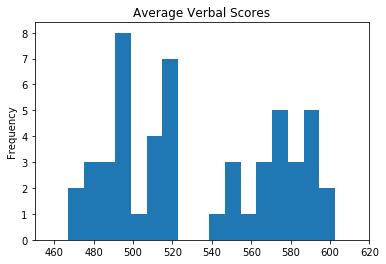

```python
ax = df["Total.Verbal"].plot.hist(title="Average Verbal Scores", bins=17)
ax.set_xlim(450, 620)

ax
```

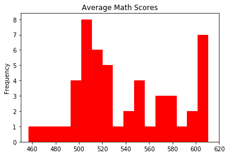

```python
ax = df["Total.Math"].plot.hist(title="Average Math Scores", bins=17, color="red")
ax.set_xlim(450, 620)

ax
```

So we clearly see that there is a wide distribution between the range of scores. Reading bottoms out at ~470 and tops out at ~600, while math has an even wider range bottoming out at ~460 and topping out at ~610. This point difference range is highly significant, and we want to know some of the possible factors that lead to such gaps between different states. One idea that immediately pops to mind: since it is already widely known that income and SAT scores are highly correlated, perhaps states with higher median incomes are the states that are performing best on the SAT. We can briefly investigate that below.

```
Correlation between median household income and total score is: -0.2932266615297606
```

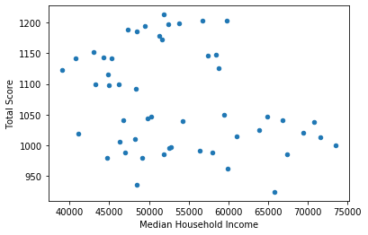

```python
df_wealth = df[["Income.Median Houseold Income"]] # Typo in table: "Houseold"
df_wealth = df_wealth.copy() # Fixes SettingWithCopyWarning
df_wealth["Total Score"] = (df["Total.Math"] + df["Total.Verbal"])
df_wealth = df_wealth.rename(columns = {"Income.Median Houseold Income" : "Median Household Income"})

df_wealth.plot.scatter(x="Median Household Income", y="Total Score")

print("Correlation between median household income and total score is: " +  str(df_wealth["Total Score"].corr(df_wealth["Median Household Income"])))
```

So we see that median household income is **NOT** a very good predictor of average total SAT score on the state level with a correlation coefficient of -.29. Additionally, the fact that the sign is negative suggests that a higher median household income negatively affects your SAT score, which we we know is not the case in reality. Higher household incomes lead to higher SAT scores on average (quickly proven below), so a higher median household income should lead to higher SAT scores on average as well.

```python
df_temp = df[["Family Income.Less than 20k.Math", "Family Income.Less than 20k.Verbal",
        "Family Income.Between 20-40k.Math", "Family Income.Between 20-40k.Verbal",
        "Family Income.Between 40-60k.Math", "Family Income.Between 40-60k.Verbal",
        "Family Income.Between 60-80k.Math", "Family Income.Between 60-80k.Verbal",
        "Family Income.Between 80-100k.Math", "Family Income.Between 80-100k.Verbal"]]

df_temp = df_temp.copy() # Fixes SettingWithCopy Errors

df_wealthxscores = pd.DataFrame()

df_wealthxscores["<20k Total Score"] = df_temp["Family Income.Less than 20k.Math"] + df_temp["Family Income.Less than 20k.Verbal"]
df_wealthxscores["20-40k Total Score"] = df_temp["Family Income.Between 20-40k.Math"] + df_temp["Family Income.Between 20-40k.Verbal"]
df_wealthxscores["40-60k Total Score"] = df_temp["Family Income.Between 40-60k.Math"] + df_temp["Family Income.Between 40-60k.Verbal"]
df_wealthxscores["60-80k Total Score"] = df_temp["Family Income.Between 60-80k.Math"] + df_temp["Family Income.Between 60-80k.Verbal"]
df_wealthxscores["80-100k Total Score"] = df_temp["Family Income.Between 80-100k.Math"] + df_temp["Family Income.Between 80-100k.Verbal"]

print("<20k household average total score: " + str(df_wealthxscores["<20k Total Score"].mean()))
print("20-40k household average total score: " + str(df_wealthxscores["20-40k Total Score"].mean()))
print("40-60k household average total score: " + str(df_wealthxscores["40-60k Total Score"].mean()))
print("60-80k household average total score: " + str(df_wealthxscores["60-80k Total Score"].mean()))
print("80-100k household average total score: " + str(df_wealthxscores["80-100k Total Score"].mean()))
```

```
<20k household average total score: 933.9975490196078
20-40k household average total score: 1010.1715686274509
40-60k household average total score: 1052.6470588235295
60-80k household average total score: 1073.985294117647
80-100k household average total score: 1096.0857843137255
```

So ultimately, we can not chalk up this difference in scores to differences median household income i.e. differences in wealth or income on the state level.

# ANALYSIS, HYPOTHESIS TESTING, & ML

Now, let us investigate one of our initial questions:

- Do states with a higher rate of languages other than English at home typically see a lower SAT verbal score?

**Conjecture**: States with higher rates of languages other than English at home do indeed see a lower SAT verbal score in general.

```python
df_language = df[["State", "Total.Math", "Total.Verbal", "Miscellaneous.Language Other than English at Home"]].rename(
    columns={"Total.Math" : "Average Math", "Total.Verbal" : "Average Verbal", "Miscellaneous.Language Other than English at Home" : "% Other Language at Home"})

df_language.head()
```

|  | State | Average Math | Average Verbal | % Other Language at Home |
| --- | --- | --- | --- | --- |
| 0 | Alabama | 547.000 | 552.500 | 5.2 |
| 1 | Alaska | 517.875 | 519.750 | 16.2 |
| 2 | Arizona | 525.875 | 518.500 | 26.8 |
| 3 | Arkansas | 570.625 | 571.375 | 7.2 |
| 4 | California | 515.625 | 498.750 | 43.7 |

Let's draw ensure the dtypes are correct and create a scatterplot to get a feel for the data.

```python
df_language.dtypes
```

```
State                        object
Average Math                float64
Average Verbal              float64
% Other Language at Home    float64
dtype: object
```

```
Corrleation between % Other Language at Home and Average Verbal is -0.4340229896191231
```

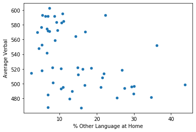

```python
df_language.plot.scatter(x="% Other Language at Home", y="Average Verbal")

print("Corrleation between % Other Language at Home and Average Verbal is " + str(df_language["Average Verbal"].corr(df_language["% Other Language at Home"])))
```

So there does seem to be somewhat of a negative correlation between **% Other Language at Home** and **Average Verbal** score i.e. a higher **% Other Language at Home** may be indicative of a lower **Average Verbal** score, but we can not immediately make conclusive statements. One issue that comes to mind is: what if states with a higher **% of Other Language at Home** are states that perform worse on the SATs in general due to other factors (i.e. there is some uninvestigated *collinearity* between **% of Other Language at Home** and other variables that may or may not be present in our data set.)  
We will look into ways to account for this, and one tool we will use here is the very strong correlation between **Average Math** scores and **Average Verbal** scores.

```
Correlation between Average Math and Average Verbal is 0.9793670202895195
```

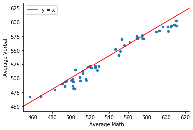

```python
temp_df = pd.DataFrame({"temp_x" : [450, 625], "y = x" : [450, 625]})

ax = temp_df.plot(kind="line", x="temp_x", y="y = x", color="red")
df_language.plot(kind="scatter", x="Average Math", y="Average Verbal", ax=ax)

print("Correlation between Average Math and Average Verbal is " + str(df_language["Average Math"].corr(df_language["Average Verbal"])))
```

That is to say, average math score is a very good predictor of average reading score. Then we can investigate average reading score as a % of average math score and see if **% Other Language at Home** explains any underpeformance of reading scores relative to math scores. We want to see if states with a relatively higher **% Other Language at Home** are also the states that fall below the y = x line on the above scatterplot.

# ------------------------------NORMALIZATION EXPLAINED------------------------------

**Question: Why do you use this sort of normalization? Why not normalize in the standard way with the average reading score across all states?**

If we used the standard normalization, states with lower quality education systems that also see a higher prevalence of non-English languages at home would still appear to underperform simply due to the lower quality education system because they are already performing below average, so the standard normalization does not do a good job of eliminating this collinearity. When we use the transformed % of average math score, we know that states with lower qualtiy education systems will be performing worse on the math section anyway, so it eliminates this collinearity worry to a good extent. Recall are looking to see if a higher % of other language at home explains the underperformance of average reading score relative to average math score. See the **bold** section below for more detail.

## Rather than identifying current relevant data and/or loading in new data and performing a multilinear regression to obtain values for predicted average verbal score, which will most certainly not be able to consider every single aspect that may affect real average verbal score, we are simply using the following idea:

## PREDICTED AVERAGE VERBAL SCORE = REAL AVERAGE MATH SCORE

## The correlation between the two is .98. It is basically the best way to model predicted average verbal score. Nearly every aspect relating to wealth, strength of education system, etc. on a state-by-state basis will be encapsulated in the real average math score. Some points, however, deviate from this prediction, but what factors might explain this?: such factors that do not affect average math score but could affect averageverbal score, e.g. lower exposure to the English language at home.

```
Correlation between % Other Language at Home and Average Verbal is -0.42142557481704546
```

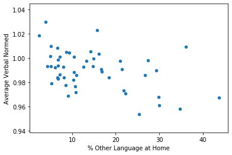

```python
df_language["Average Verbal Normed"] = df_language["Average Verbal"] / df_language["Average Math"]

df_language.plot.scatter(x="% Other Language at Home", y="Average Verbal Normed")

print("Correlation between % Other Language at Home and Average Verbal is " + str(df_language["Average Verbal Normed"].corr(df_language["% Other Language at Home"])))
```

The correlation coefficient is nearly the same! That is, with this transformation of the variable, the data still (weakly) suggests that a state with a higher **% Other Language at Home** performs relatively worse on the verbal section than states with a lower %. Although we still reached the same conclusion, this is a good example of why it is important to transform variables and look at trends from different perspectives.

See below for some points of interest:

```python
# 5 lowest performing states for Average Verbal Normed
df_language.loc[df_language["Average Verbal Normed"] < .9688]

# Note all states have a % Other Language at Home > 25%
```

|  | State | Average Math | Average Verbal | % Other Language at Home | Average Verbal Normed |
| --- | --- | --- | --- | --- | --- |
| 4 | California | 515.625 | 498.75 | 43.7 | 0.967273 |
| 11 | Hawaii | 504.250 | 481.00 | 25.4 | 0.953892 |
| 30 | New Jersey | 516.375 | 496.25 | 30.0 | 0.961026 |
| 32 | New York | 502.250 | 486.25 | 29.9 | 0.968143 |
| 43 | Texas | 502.875 | 481.75 | 34.7 | 0.957992 |

```python
# The highest peforming state with average verbal normalzied
df_language.iloc[df_language["Average Verbal Normed"].idxmax()]

# Note the very low % Other Language at Home: only ~4%
```

```
State                       Mississippi
Average Math                    553.125
Average Verbal                  569.625
% Other Language at Home            3.9
Average Verbal Normed           1.02983
Name: 24, dtype: object
```

Let's explore one more question from our list:

- Do states with a more stable home life perform better on the SAT?

This is a bit of an open-ended question. We know what it means to perform better on the SAT, that's simply a higher average total score. But what is a more stable home life vs. a less stable home life? We are going to use two arbitrary but reasonable criteria in our definition:

1. A higher rate of homeowners who have owned and lived in the same house for 1+ years is indicative of a state with a generally more stable home life than one with a lower rate. The same house 1+ years criterion clearly relates to our notion of "stability" in home life: same area, same school, same people, same activities, etc. in the student's life for a longer and continuous period of time. Homeownership implies that the family has intentions of remaining there and can be associated with stability.
2. A lower average commute time is indicative of a state with a generally more stable home life than a state with a higher average commute time. We are making the assumption that if a parent has a lower commute time and thus more free time, the parent will spend some of this time with his/her child and that this is beneficial to the child's academic success.

So we are assuming here that staying in the same home, and thus usually the same school district/community, is beneificial to a student's academic success. We are also assuming that parents who have lower commute times spend more time with their children on average, and this is beneficial to a child's academic success (should be true especially in the earlier years of schooling.) These are both reasonable assumptions.

Let's pull the relevant columns. The State Demographics data set contains average commute times, homeownership rates, and living in same house 1+ years, which is everything that we are looking for to combine with the SAT scores. We will also create a calculated column called **Stable Home Rate** that is **Same House 1+ Years** * **Homeownership Rate** as a percentage. Essentially, it is the percentage of households that own their home and have been living there for 1 or more years.

```python
df_homelife = df[["State", "Total.Math", "Total.Verbal", "Miscellaneous.Mean Travel Time to Work", "Miscellaneous.Living in Same House +1 Years", "Housing.Homeownership Rate"]].rename(
    columns={"Total.Math" : "Average Math", "Total.Verbal" : "Average Verbal", "Miscellaneous.Mean Travel Time to Work" : "Average Commute Time", "Miscellaneous.Living in Same House +1 Years" : "Same House 1+ Years Rate", "Housing.Homeownership Rate" : "Homeownership Rate"})

df_homelife["Stable Home Rate"] = (df_homelife["Same House 1+ Years Rate"] * df_homelife["Homeownership Rate"]) / 100

df_homelife.head()
```

|  | State | Average Math | Average Verbal | Average Commute Time | Same House 1+ Years Rate | Homeownership Rate | Stable Home Rate |
| --- | --- | --- | --- | --- | --- | --- | --- |
| 0 | Alabama | 547.000 | 552.500 | 24.2 | 85.0 | 69.7 | 59.2450 |
| 1 | Alaska | 517.875 | 519.750 | 18.8 | 80.3 | 63.8 | 51.2314 |
| 2 | Arizona | 525.875 | 518.500 | 24.6 | 80.4 | 64.4 | 51.7776 |
| 3 | Arkansas | 570.625 | 571.375 | 21.3 | 83.6 | 66.7 | 55.7612 |
| 4 | California | 515.625 | 498.750 | 27.2 | 84.2 | 55.3 | 46.5626 |

Box plot of **Stable Home Rate**. We see a good range of possible values, so that gives us some hope for explaining the range in values of SAT scores.

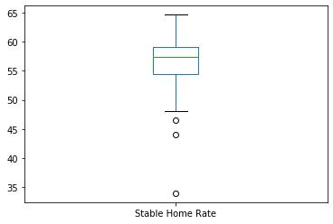

```python
df_homelife["Stable Home Rate"].plot.box()
```

Box plot of **Average Commute Time**, again we see a good range of values.

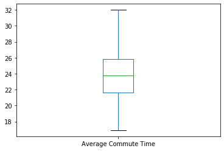

```python
df_homelife["Average Commute Time"].plot.box()
```

In order to make our analysis a litter easier and more general, we are going to split both **Stable Home Rate** and **Average Commute Time** into 3 categories:

1. low: states with values in the bottom 1/3.
2. medium: states with values in the middle 1/3.
3. high: states with values in the top 1/3.

This is an arbitrary split, but something of this sort is needed to transform these variables into ordinal values.

```python
print(df_homelife["Stable Home Rate"].min())
print(df_homelife["Stable Home Rate"].quantile(.33))
print(df_homelife["Stable Home Rate"].quantile(.66))
print(df_homelife["Stable Home Rate"].max())
```

```
33.9326
55.7861
58.527699999999996
64.6654
```

```python
print(df_homelife["Average Commute Time"].min())
print(df_homelife["Average Commute Time"].quantile(.33))
print(df_homelife["Average Commute Time"].quantile(.66))
print(df_homelife["Average Commute Time"].max())
```

```
16.9
22.85
24.8
32.0
```

We will create two new calculated columns for the categories of **Stable Home Rate** and **Average Commute Time**.

```python
def get_shr_category(val):

    if val < 55.7861:
        return "low"
    elif val >= 55.7861 and val < 58.528:
        return "medium"
    else:
        return "high"

def get_act_category(val):

    if val < 22.85:
        return "low"
    elif val >= 22.85 and val < 24.81:
        return "medium"
    else:
        return "high"

shr_categories_list = [get_shr_category(j) for j in df_homelife["Stable Home Rate"]]
act_categories_list = [get_act_category(k) for k in df_homelife["Average Commute Time"]]

df_homelife["Stable Home Rate Category"] = shr_categories_list
df_homelife["Average Commute Time Category"] = act_categories_list
df_homelife["Average Math + Verbal"] = df_homelife["Average Math"] + df_homelife["Average Verbal"]

df_homelife.head()
```

|  | State | Average Math | Average Verbal | Average Commute Time | Same House 1+ Years Rate | Homeownership Rate | Stable Home Rate | Stable Home Rate Category | Average Commute Time Category | Average Math + Verbal |
| --- | --- | --- | --- | --- | --- | --- | --- | --- | --- | --- |
| 0 | Alabama | 547.000 | 552.500 | 24.2 | 85.0 | 69.7 | 59.2450 | high | medium | 1099.500 |
| 1 | Alaska | 517.875 | 519.750 | 18.8 | 80.3 | 63.8 | 51.2314 | low | low | 1037.625 |
| 2 | Arizona | 525.875 | 518.500 | 24.6 | 80.4 | 64.4 | 51.7776 | low | medium | 1044.375 |
| 3 | Arkansas | 570.625 | 571.375 | 21.3 | 83.6 | 66.7 | 55.7612 | low | low | 1142.000 |
| 4 | California | 515.625 | 498.750 | 27.2 | 84.2 | 55.3 | 46.5626 | low | high | 1014.375 |

Now we can create a crosstable to take a look at the counts in each cell in order to ensure that this was a reasonable split, and all the states are not just contained within a select few cells.

```python
xtab = pd.crosstab(df_homelife["Stable Home Rate Category"], df_homelife["Average Commute Time Category"])
xtab = xtab[["low", "medium", "high"]]
xtab = xtab.reindex(["low", "medium", "high"])

xtab
```

| Average Commute Time Category Stable Home Rate Category | low | medium | high |
| --- | --- | --- | --- |
| low | 5 | 4 | 8 |
| medium | 9 | 5 | 3 |
| high | 3 | 8 | 6 |

So the counts look reasonable, so we did a good job of categorizing the quantities. Now that we have checked this, we can go on to compute average scores for each of the (Stable Home Rate Category, Average Commute Time Category) pairs:

1. (low, low)
2. (low, medium)
3. (low, high)
4. (medium, low)
5. (medium, medium)
6. (medium, high)
7. (high, low)
8. (high, medium)
9. (high, high)

**Conjecture**: (Stable Home Rate Category = low, Average Commute Time Category = high) will perform the worst on the SAT on average and (Stable Home Rate Category = high, Average Commute Time Category = low) will perform the best on average.

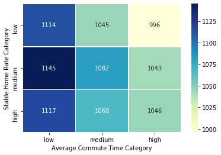

```python
import seaborn as sns

xtable = pd.pivot_table(df_homelife, values="Average Math + Verbal", index="Stable Home Rate Category", columns="Average Commute Time Category", aggfunc=np.mean, fill_value=0)
xtable = xtable[["low", "medium", "high"]]
xtable = xtable.reindex(["low", "medium", "high"])
xtable = np.round(xtable)

xtable["low"] = xtable["low"].astype(int)
xtable["medium"] = xtable["medium"].astype(int)
xtable["high"] = xtable["high"].astype(int)
sns.heatmap(xtable, cmap="YlGnBu", linewidths=0.5, annot=True, fmt="d")
```

So we see that we are right on 1 account: (Stable Home Rate Category = low, Average Commute Time Category = high) was indeed the worst performer. (Stable Home Rate Category = high, Average Commute Time Category = low) was not *the* best performer, but it was second best, so we were pretty close with our original conjecture. Additionally, wee see trends that scores always go down from left to right (low average commute time -> high average commute time.) We do not see the same effect when going from top to bottom (low stable home rate -> high stable rate) as states in the medium category seem to perform better than states with high stable home rates of the same commute time category. If you are viewing this as the .ipynb, feel free to change the `shr` (stable home rate category) and `act` (average commute time category) below to see what states fall into which slice if you want to explore why medium stable home rate states are outperforming high stable home rate states.

```python
shr = "medium"
act = "low"

df_homelife.loc[(df_homelife["Stable Home Rate Category"] == shr) & (df_homelife["Average Commute Time Category"] == act)]
```

|  | State | Average Math | Average Verbal | Average Commute Time | Same House 1+ Years Rate | Homeownership Rate | Stable Home Rate | Stable Home Rate Category | Average Commute Time Category | Average Math + Verbal |
| --- | --- | --- | --- | --- | --- | --- | --- | --- | --- | --- |
| 12 | Idaho | 519.875 | 520.375 | 20.0 | 82.8 | 69.8 | 57.7944 | medium | low | 1040.250 |
| 16 | Kansas | 593.000 | 584.625 | 19.0 | 83.2 | 67.5 | 56.1600 | medium | low | 1177.625 |
| 17 | Kentucky | 575.500 | 576.375 | 22.8 | 84.8 | 68.4 | 58.0032 | medium | low | 1151.875 |
| 26 | Montana | 551.875 | 548.125 | 18.0 | 83.6 | 68.3 | 57.0988 | medium | low | 1100.000 |
| 27 | Nebraska | 589.875 | 583.125 | 18.1 | 83.3 | 67.0 | 55.8110 | medium | low | 1173.000 |
| 41 | South Dakota | 602.000 | 591.875 | 16.9 | 83.6 | 68.0 | 56.8480 | medium | low | 1193.875 |
| 44 | Utah | 561.500 | 564.500 | 21.4 | 82.8 | 70.1 | 58.0428 | medium | low | 1126.000 |
| 49 | Wisconsin | 605.250 | 591.750 | 21.7 | 85.8 | 68.1 | 58.4298 | medium | low | 1197.000 |
| 50 | Wyoming | 575.250 | 571.625 | 18.3 | 81.8 | 70.1 | 57.3418 | medium | low | 1146.875 |

Let's address the following concern: what if **Stable Home Rate** and **Average Commute Time** are just very good proxies for income?

```
Correlation between median household income and stable home rate: -0.2724865208430047
```

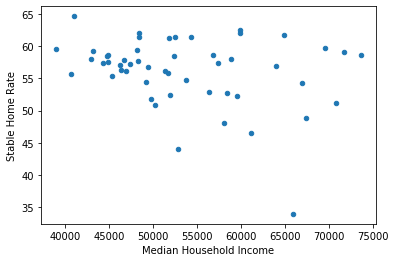

```python
df_temp2 = pd.DataFrame()
df_temp2["Median Household Income"] = df_wealth["Median Household Income"]
df_temp2["Stable Home Rate"] = df_homelife["Stable Home Rate"]

df_temp2.plot.scatter(x="Median Household Income", y="Stable Home Rate")
print("Correlation between median household income and stable home rate: " + str(df_temp2["Median Household Income"].corr(df_temp2["Stable Home Rate"])))
```

```
Correlation between median household income and average commute time: 0.41909444933002626
```

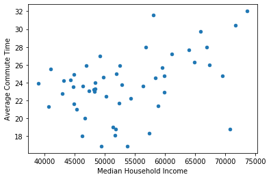

```python
df_temp2["Average Commute Time"] = df_homelife["Average Commute Time"]

df_temp2.plot.scatter(x="Median Household Income", y="Average Commute Time")
print("Correlation between median household income and average commute time: " + str(df_temp2["Median Household Income"].corr(df_temp2["Average Commute Time"])))
```

So stable home rate is certainly not a good proxy for income, and average commute time may be a weak proxy for income. Regardless, neither are very good proxies for income, so that worry can be alleviated.

# INSIGHT AND POLICY DECISION

We saw that median household income and average total score do not have a strong positive correlation on the state level, so we were looking to see what other factors might help explain such drastic differences between scores from state to state. % Other Language at Home was one variable we investigated, and our analysis weakly - moderately suggests that having a higher % language other than English at home in a state does negatively impact the SAT verbal score in general. This analysis was done moreso to get some insight rather than suggest authoritarian policy decisions on what languages you can and can not speak at home.

Additionally, we looked at average commute time and average stable home rate. The heatmap suggests that, indeed, a lower average commute time and higher stable home rate is generally beneficial to a student's performance on the SATs. Here, policy insight might be a little more applicable. States may be able to implement policies that encourage homeownership and higher stability of living situations, and they may be able to lower average commute times through improvements to highways, roads, etc. The specifics of such policy decisions are best left to the experts who can more appropriately evaluate possibilities and cost/benefits of related legislation.